# L03 Tidy Data

Data Science 1 with R (STAT 301-1)

Author

Olivia Allen

Published

October 20, 2024

**Github Repo Link✅**

https://github.com/stat301-1-2024-fall/L03-tidy-data-oliviaallen2003.git

## Load packages✅

```r
# Loading package(s)
library(tidyverse)
library(ggplot2)
library(dplyr)
library(fivethirtyeight)
```

## Datasets ✅

```r
# Load dataset(s)
users_top7_2020 <- read_csv("data/users_top7_2020.csv")
```

## Exercises✅

### Exercise 1 ✅

Recreate the plot below showing the change in cases over time using `table2`. What do you need to do first?

**Solution**

In the initial data set, table2 was in the long format and the ‘type’ column included two different categories, cases and population. In order to recreate the plot, you need to first reformat the data using pivot_wider() to create different columns for cases and population.

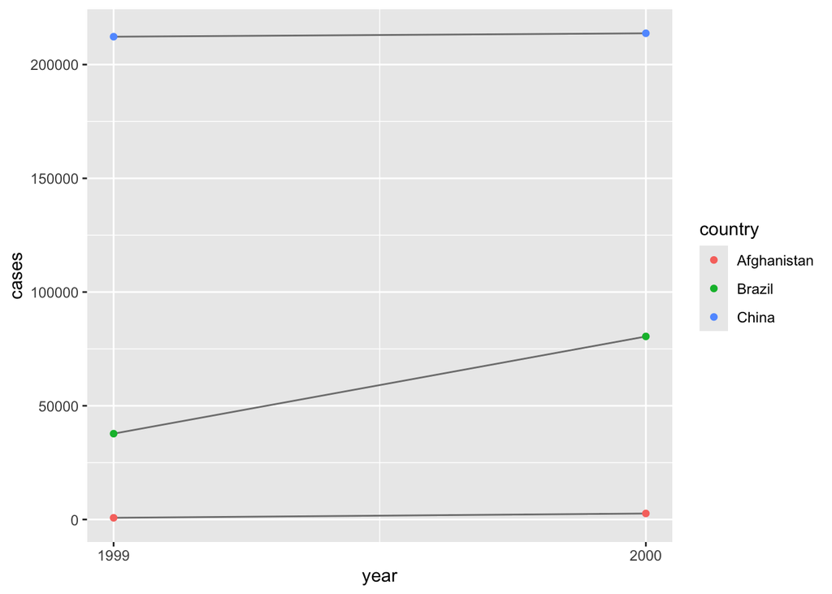

```r
cases_data <- table2 |>
  pivot_wider(names_from = type, values_from = count)

ggplot(cases_data, aes(x = year, y = cases, group = country)) +
  geom_line(color = "grey50") +
  geom_point(aes(color = country)) +
  scale_x_continuous(breaks = c(1999, 2000)) +
  labs(x = "year", y = "cases")
```

### Exercise 2✅

Tidy the simple tibble of [M&M](https://en.wikipedia.org/wiki/M%26M%27s) data below and drop the NA values.

Do you need to make it wider or longer? What are the variables in your tidy version? What argument drops the NA values?

```r
# simple tibble of M&M data
mm_data <- tribble(
  ~mm_type, ~blue, ~orange, ~green, ~yellow, ~brown, ~red, ~cyan_blue,
  "plain",  6,     18,      12,     6,       7,      7,    NA,
  "peanut", NA,    11,      9,      1,       12,       8,    15
)
```

**Solution**

```r
mm_tidy <- mm_data |>
  pivot_longer(cols = -mm_type, names_to = "color", values_to = "count") |>
  drop_na()

mm_tidy
```

```
# A tibble: 12 × 3
   mm_type color     count
   <chr>   <chr>     <dbl>
 1 plain   blue          6
 2 plain   orange       18
 3 plain   green        12
 4 plain   yellow        6
 5 plain   brown         7
 6 plain   red           7
 7 peanut  orange       11
 8 peanut  green         9
 9 peanut  yellow        1
10 peanut  brown        12
11 peanut  red           8
12 peanut  cyan_blue    15
```

The dataset needs to be made longer. The original dataset is in wide format where each color has its own column. The dataset can be made longer using pivot_longer() so that each variable can have its own column. The variables in my tidy version are mm_type which is type of M&M, color which is the color of each M&M and count, which is the count for each type and color. The drop_na function is used to drop the NA values from the dataset.

### Exercise 3✅

Use `table4a` and **only** the `pivot_longer` function to recreate the following:

**Solution**

```r
table4a |>
  pivot_longer(cols = c('1999', '2000'),
               names_to = "year",
               values_to = "cases")
```

```
# A tibble: 6 × 3
  country     year   cases
  <chr>       <chr>  <dbl>
1 Afghanistan 1999     745
2 Afghanistan 2000    2666
3 Brazil      1999   37737
4 Brazil      2000   80488
5 China       1999  212258
6 China       2000  213766
```

### Exercise 4✅

Use the `drinks` dataset and **only** the `pivot_longer` function to recreate the following:

**Solution**

```r
drinks %>%
 pivot_longer(
   cols = c(beer_servings, spirit_servings, wine_servings),
   names_to = "type",
   values_to = "servings",
   names_pattern = "(.*)_servings"
 )
```

```
# A tibble: 579 × 4
   country     total_litres_of_pure_alcohol type   servings
   <chr>                              <dbl> <chr>     <int>
 1 Afghanistan                          0   beer          0
 2 Afghanistan                          0   spirit        0
 3 Afghanistan                          0   wine          0
 4 Albania                              4.9 beer         89
 5 Albania                              4.9 spirit      132
 6 Albania                              4.9 wine         54
 7 Algeria                              0.7 beer         25
 8 Algeria                              0.7 spirit        0
 9 Algeria                              0.7 wine         14
10 Andorra                             12.4 beer        245
# ℹ 569 more rows
```

### Exercise 5✅

What happens if you use `pivot_wider()` on this table so that we have a dataset with 3 columns (`respondent_name`, `age`, `height`) and why?

Fix the issue by adding a new column.

```r
# dataset/table
people <- tribble(
  ~respondent_name,  ~key,    ~value,
  #-----------------|--------|------
  "Phillip Woods",   "age",       45,
  "Phillip Woods",   "height",   186,
  "Phillip Woods",   "age",       50,
  "Jessica Cordero", "age",       37,
  "Jessica Cordero", "height",   156
)
```

**Solution**

When you use pivot_wider() on this table to create a dataset with 3 columns (`respondent_name`, `age`, `height`), it results in an error because the data for Phillip Woods has two conflicting values for age. The function will use one unique value for each respondent_name and key but because Phillip Woods has two different ages, R doesn’t know which one to use.

```r
people_fixed <- tribble(
  ~respondent_name,   ~key,     ~value,  ~time,
  "Phillip Woods",    "age",    45,       "t1",
  "Phillip Woods",    "height", 186,      "t1",
  "Phillip Woods",    "age",    50,       "t2",
  "Jessica Cordero",  "age",    37,       "t1",
  "Jessica Cordero",  "height", 156,      "t1"
)

people_fixed |>
  pivot_wider(
    names_from = key,
    values_from = value
  )
```

```
# A tibble: 3 × 4
  respondent_name time    age height
  <chr>           <chr> <dbl>  <dbl>
1 Phillip Woods   t1       45    186
2 Phillip Woods   t2       50     NA
3 Jessica Cordero t1       37    156
```

## Case Study✅

**Solution**

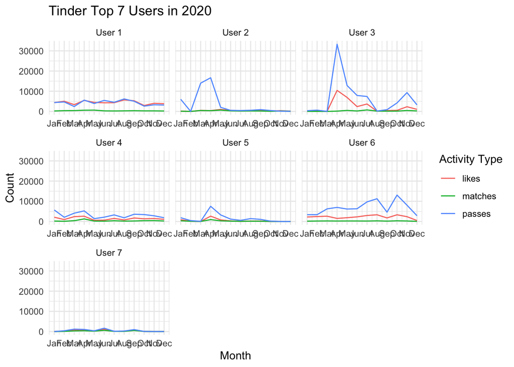

```r
users_top7_2020$user_number <- paste("User", 1:7)

longer_data <- users_top7_2020 |>
  pivot_longer(
    cols = starts_with("matches_") | starts_with("likes_") | starts_with("passes_"),
    names_to = c("metric", "month"),
    names_sep = "_",
    values_to = "value"
  )

longer_data$month <- as.numeric(longer_data$month)

ggplot(longer_data, aes(x = month, y = value, color = metric)) +
  geom_line() +
  facet_wrap(~user_number, scales = "free_x") +
  labs(
    title = "Tinder Top 7 Users in 2020",
    x = "Month",
    y = "Count",
    color = "Activity Type"
  ) +
  scale_x_continuous(
    breaks = 1:12,
    labels = c("Jan", "Feb", "Mar", "Apr", "May", "Jun", "Jul", "Aug", "Sep", "Oct", "Nov", "Dec")
  ) +
  theme_minimal()
```